# Report - Project Machine Learning - Predict Types of Exercises

Leonardo Alves

November 18, 2016

## Introduction

One thing that people regularly do is quantify how much of a particular activity they do, but they rarely quantify how well they do it. The goal of this project was to use data from accelerometers on the belt, forearm, arm, and dumbell of 6 participants (Velloso et all, 2013) and predict the manner in which they did the exercise using machine learning approach. The “classe” variable in the training set has the information about the manner.

The main questions and points of this report:

1. How the model was built?
2. How cross validation was used?
3. Discuss about sample error and the choices made
4. Use the prediction model to predict 20 different test cases

## Data Preparation

The data was donwloaded and two datasets were assigned (training and testing).

```r
# Downloading datasets
fileUrl1 <- "https://d396qusza40orc.cloudfront.net/predmachlearn/pml-training.csv"
download.file(fileUrl1,destfile="training.csv",method="curl")
fileUrl2 <- "https://d396qusza40orc.cloudfront.net/predmachlearn/pml-testing.csv"
download.file(fileUrl2,destfile="testing.csv",method="curl")

#Training data
training <- read.csv("training.csv")
#Testing data
testing <- read.csv("testing.csv")
```

There are many models where predictors with a single unique value (also know as “zero-variance predictor”) will cause the model to fail. To prevent this problem, the function nearZeroVar from caret package was used to exclude these predictors.

```r
# Package Caret
library(caret)
# Deleting near zero-variance predictors:
# 1 - the percentage of unique values is less than 20% and
# 2 - the ratio of the most frequent to the second most frequent value is greater than 20
training <- training[, -nearZeroVar(training)]
dim(training)
```

```
## [1] 19622   100
```

```r
testing <- testing[, -nearZeroVar(testing)]
dim(testing)
```

```
## [1] 20 59
```

The columns with NAs in the training set were deleted and the first variable (X) of each dataset was exclude because they are just a sequence of numbers.

```r
training <- training[ , colSums(is.na(training)) == 0]
training$X <- NULL
testing$X <- NULL
dim(training)
```

```
## [1] 19622    58
```

```r
dim(testing)
```

```
## [1] 20 58
```

```r
#variables in the new training set
str(training)
```

```
## 'data.frame':    19622 obs. of  58 variables:
##  $ user_name           : Factor w/ 6 levels "adelmo","carlitos",..: 2 2 2 2 2 2 2 2 2 2 ...
##  $ raw_timestamp_part_1: int  1323084231 1323084231 1323084231 1323084232 1323084232 1323084232 1323084232 1323084232 1323084232 1323084232 ...
##  $ raw_timestamp_part_2: int  788290 808298 820366 120339 196328 304277 368296 440390 484323 484434 ...
##  $ cvtd_timestamp      : Factor w/ 20 levels "02/12/2011 13:32",..: 9 9 9 9 9 9 9 9 9 9 ...
##  $ num_window          : int  11 11 11 12 12 12 12 12 12 12 ...
##  $ roll_belt           : num  1.41 1.41 1.42 1.48 1.48 1.45 1.42 1.42 1.43 1.45 ...
##  $ pitch_belt          : num  8.07 8.07 8.07 8.05 8.07 8.06 8.09 8.13 8.16 8.17 ...
##  $ yaw_belt            : num  -94.4 -94.4 -94.4 -94.4 -94.4 -94.4 -94.4 -94.4 -94.4 -94.4 ...
##  $ total_accel_belt    : int  3 3 3 3 3 3 3 3 3 3 ...
##  $ gyros_belt_x        : num  0 0.02 0 0.02 0.02 0.02 0.02 0.02 0.02 0.03 ...
##  $ gyros_belt_y        : num  0 0 0 0 0.02 0 0 0 0 0 ...
##  $ gyros_belt_z        : num  -0.02 -0.02 -0.02 -0.03 -0.02 -0.02 -0.02 -0.02 -0.02 0 ...
##  $ accel_belt_x        : int  -21 -22 -20 -22 -21 -21 -22 -22 -20 -21 ...
##  $ accel_belt_y        : int  4 4 5 3 2 4 3 4 2 4 ...
```

[output cut: 44 more lines]

We reduced the number of variables in the datasets from 160 to 58 following the steps above.

## Building and Tuning Models

Our response variable “classe” has five levels (A, B, C, D and E). The response is a factor variable. We decided to build and tuning two different types of model: Random Forest and Support Vector Machine (SVM). These models are powerful and very flexible for situations like that, where we have predict the correct classe (five possible classes).

The Repeated K-fold CV was used as resampling method (10 fold, repeated 3 times). This method is robust and almost unbiased. For example, the default method (Bootstrapping) has low variance but non-zero bias when compared to K-fold CV.

Once the final set of predictors was determined, the values required transformations before being used in the models. Some models, such as partial least squares, neural networks and support vector machines, need the predictor variables to be centered and/or scaled (Kuhn, 2008). For this reason, in this project the training datasets where centered and scaled (preProc = c(“center”, “scale”)).

It was not possible to measure error (RMSE) considering the classification models (RF and SVM) because the response is a factor variable. The error can be measured as percentage of correct predictions. The accuracy and Kappa were considered the perfomance measures to help choose the best model.

The Tunelength = 5 was choosed for both models. The methods in the train function were “RF” to Random Forest and “SvmRadial” to Support Vector Machine.

Most of these parameters were choosed following the suggestions finding in the article: “Kuhn, M. Building Predictive Models Using the caret Package. Journal of Statistical Software. Vol. 28, Issue 5, 2008”.

Parallel processing was used to make computations faster (libraries foreach and doMC).

### Random Forest Model

```
## Random Forest
##
## 14718 samples
##    57 predictors
##     5 classes: 'A', 'B', 'C', 'D', 'E'
##
## Pre-processing: centered (79), scaled (79)
## Resampling: Cross-Validated (10 fold, repeated 3 times)
## Summary of sample sizes: 13247, 13246, 13247, 13246, 13245, 13246, ...
## Resampling results across tuning parameters:
##
##   mtry  Accuracy   Kappa
##    2    0.9906916  0.9882239
##   21    0.9991394  0.9989115
##   40    0.9993205  0.9991406
##   59    0.9991621  0.9989401
##   79    0.9986639  0.9983100
##
## Accuracy was used to select the optimal model using  the largest value.
## The final value used for the model was mtry = 40.
```

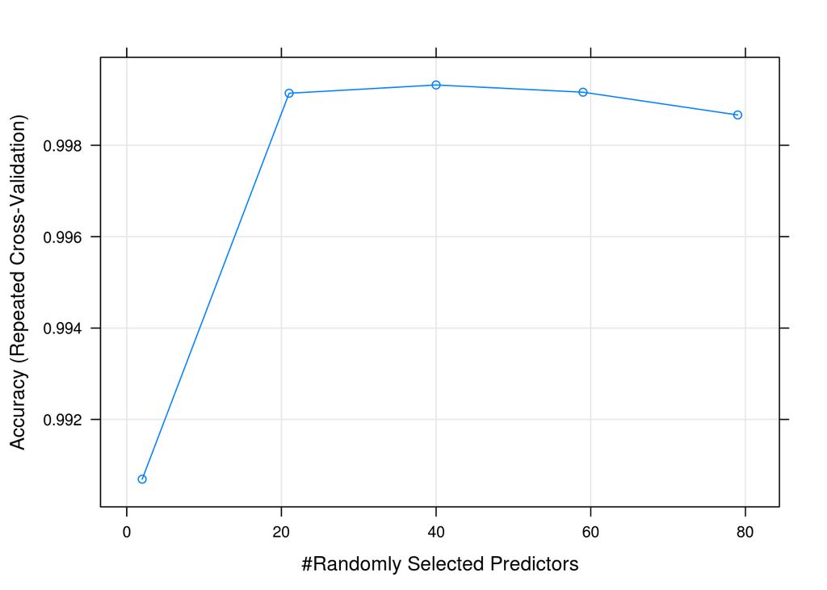

```
## $positive
## NULL
##
## $table
##           Reference
## Prediction    A    B    C    D    E
##          A 1395    0    0    0    0
##          B    0  948    1    0    0
##          C    0    1  854    3    0
##          D    0    0    0  800    0
##          E    0    0    0    1  901
##
## $overall
##       Accuracy          Kappa  AccuracyLower  AccuracyUpper   AccuracyNull
##      0.9987765      0.9984524      0.9973389      0.9995509      0.2844617
## AccuracyPValue  McnemarPValue
##      0.0000000            NaN
##
## $byClass
##          Sensitivity Specificity Pos Pred Value Neg Pred Value Precision
## Class: A   1.0000000   1.0000000      1.0000000      1.0000000 1.0000000
## Class: B   0.9989463   0.9997472      0.9989463      0.9997472 0.9989463
## Class: C   0.9988304   0.9990121      0.9953380      0.9997528 0.9953380
## Class: D   0.9950249   1.0000000      1.0000000      0.9990253 1.0000000
## Class: E   1.0000000   0.9997502      0.9988914      1.0000000 0.9988914
##             Recall        F1 Prevalence Detection Rate
## Class: A 1.0000000 1.0000000  0.2844617      0.2844617
## Class: B 0.9989463 0.9989463  0.1935155      0.1933116
## Class: C 0.9988304 0.9970811  0.1743475      0.1741436
## Class: D 0.9950249 0.9975062  0.1639478      0.1631321
## Class: E 1.0000000 0.9994454  0.1837276      0.1837276
##          Detection Prevalence Balanced Accuracy
## Class: A            0.2844617         1.0000000
## Class: B            0.1935155         0.9993467
## Class: C            0.1749592         0.9989213
## Class: D            0.1631321         0.9975124
## Class: E            0.1839315         0.9998751
##
## $mode
## [1] "sens_spec"
##
## $dots
## list()
##
## attr(,"class")
## [1] "confusionMatrix"
```

### Prediction of 20 different test cases using Random Forest

```
##
## Call:
##  randomForest(x = x, y = y, mtry = param$mtry)
##                Type of random forest: classification
##                      Number of trees: 500
## No. of variables tried at each split: 40
##
##         OOB estimate of  error rate: 0.07%
## Confusion matrix:
##      A    B    C    D    E  class.error
## A 4185    0    0    0    0 0.0000000000
## B    1 2846    1    0    0 0.0007022472
## C    0    3 2564    0    0 0.0011686794
## D    0    0    5 2407    0 0.0020729685
## E    0    0    0    0 2706 0.0000000000
```

```
##  [1] B A B A A E D B A A B C B A E E A B B B
## Levels: A B C D E
```

## Support Vector Machines (SVM)

```
## Support Vector Machines with Radial Basis Function Kernel
##
## 14718 samples
##    57 predictors
##     5 classes: 'A', 'B', 'C', 'D', 'E'
##
## Pre-processing: centered (79), scaled (79)
## Resampling: Cross-Validated (10 fold, repeated 3 times)
## Summary of sample sizes: 13247, 13246, 13247, 13246, 13245, 13246, ...
## Resampling results across tuning parameters:
##
##   C     Accuracy   Kappa
##   0.25  0.9043340  0.8789633
##   0.50  0.9285452  0.9094311
##   1.00  0.9427915  0.9275014
##   2.00  0.9549532  0.9429382
##   4.00  0.9670926  0.9583317
##
## Tuning parameter 'sigma' was held constant at a value of 0.008229052
## Accuracy was used to select the optimal model using  the largest value.
## The final values used for the model were sigma = 0.008229052 and C = 4.
```

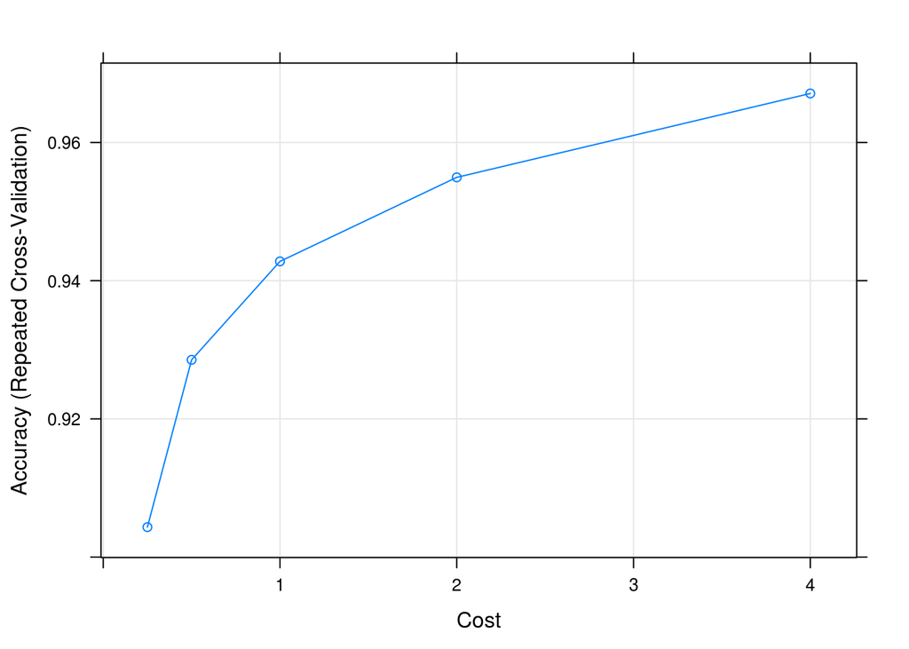

```
## $positive
## NULL
##
## $table
##           Reference
## Prediction    A    B    C    D    E
##          A 1388   46    0    0    0
##          B    2  893   27    0    0
##          C    5   10  826   65    0
##          D    0    0    2  738   16
##          E    0    0    0    1  885
##
## $overall
##       Accuracy          Kappa  AccuracyLower  AccuracyUpper   AccuracyNull
##      0.9645188      0.9550733      0.9589551      0.9695201      0.2844617
## AccuracyPValue  McnemarPValue
##      0.0000000            NaN
##
## $byClass
##          Sensitivity Specificity Pos Pred Value Neg Pred Value Precision
## Class: A   0.9949821   0.9868909      0.9679219      0.9979827 0.9679219
## Class: B   0.9409905   0.9926675      0.9685466      0.9859367 0.9685466
## Class: C   0.9660819   0.9802420      0.9116998      0.9927464 0.9116998
## Class: D   0.9179104   0.9956098      0.9761905      0.9840887 0.9761905
## Class: E   0.9822420   0.9997502      0.9988713      0.9960179 0.9988713
##             Recall        F1 Prevalence Detection Rate
## Class: A 0.9949821 0.9812655  0.2844617      0.2830343
## Class: B 0.9409905 0.9545697  0.1935155      0.1820962
## Class: C 0.9660819 0.9381034  0.1743475      0.1684339
## Class: D 0.9179104 0.9461538  0.1639478      0.1504894
## Class: E 0.9822420 0.9904868  0.1837276      0.1804649
##          Detection Prevalence Balanced Accuracy
## Class: A            0.2924144         0.9909365
## Class: B            0.1880098         0.9668290
## Class: C            0.1847471         0.9731620
## Class: D            0.1541599         0.9567601
## Class: E            0.1806688         0.9909961
##
## $mode
## [1] "sens_spec"
##
## $dots
## list()
##
## attr(,"class")
## [1] "confusionMatrix"
```

```
## Support Vector Machine object of class "ksvm"
##
## SV type: C-svc  (classification)
##  parameter : cost C = 4
##
## Gaussian Radial Basis kernel function.
##  Hyperparameter : sigma =  0.00822905190735349
##
## Number of Support Vectors : 3975
##
## Objective Function Value : -2656.687 -668.5725 -78.5055 -46.4854 -2210.716 -223.3316 -54.1176 -1617.074 -232.3204 -1284.6
## Training error : 0.028333
```

```
##  [1] B A B A A E D B A A B C B A E E A B B B
## Levels: A B C D E
```

## Results

The final model using Random Forest was selected (better measures performances in the test set: Accuracy = 0.99 Kappa = 0.99 vs Accuracy = 0.96 Kappa = 0.95 of SVM).

The predictions of 20 different test cases were similar for both models:

- Random Forest

B A B A A E D B A A B C B A E E A B B B Levels: A B C D E

- SVM

B A B A A E D B A A B C B A E E A B B B Levels: A B C D E

## References

- Velloso, E.; Bulling, A.; Gellersen, H.; Ugulino, W.; Fuks, H. Qualitative Activity Recognition of Weight Lifting Exercises. Proceedings of 4th International Conference in Cooperation with SIGCHI (Augmented Human ’13) . Stuttgart, Germany: ACM SIGCHI, 2013. Read more: http://groupware.les.inf.puc-rio.br/har#ixzz4QOQgEFuQ
- Kuhn, M. Building Predictive Models Using the caret Package. Journal of Statistical Software. Vol. 28, Issue 5, 2008.